# NOAA Storm Database - Analysis of event effects

Stefan Buchholz

Thursday, November 06, 2014

## Synopsis

The aim of this analysis is to see which type of wheather events are most harmful to humans and which events are most harmful in terms of economical damage. We extracted the relevant data of the NOAA storm dataset to answer the given questions. Our analysis will show that by far tornados are the most dangerous type of wheather event in any case either for economy or humanity.

## Data Processing

### Loading Data

Firstly the Data is downloaded from the Coursera link.

```r
url <- 'https://d396qusza40orc.cloudfront.net/repdata%2Fdata%2FStormData.csv.bz2'

if (file.exists('Storm.Data.csv.bz2') == FALSE) {
    download.file(url, dest='Storm.Data.csv.bz2') }
```

after we downloaded the data we extract the data and read it into a dataframe:

```r
library(R.utils)

#if file isnt already unzipped unzip it!
if (file.exists('Storm.Data.csv') == FALSE) {
    bunzip2('Storm.Data.csv.bz2', dest='Storm.Data.csv') }
bz <- read.csv('Storm.Data.csv')
```

The columns we need to answer our questions are EVTYPE, FATALITIES, INJURIES, PROPDMG, CROPDMG.

```r
needed <- bz[,c(8,23,24,25,27)]
table(needed$EVTYPE)
```

[output not shown]

[output cut: 932 more lines]

[output not shown]

When we explore the given Storm reasons we can see that we have to clear them up and make them more conform by:

1. delete rows where there is a “summary” because that is no interessting data
2. transform them to lower case
3. replace all special characters to blanks
4. strip blank values
5. set new levels

The reason for that is, that a lot of differnt characters are inside the type of event labels.

```r
#delete everything that looks like a summary line
filter <- grep("summar",needed$EVTYPE, ignore.case = TRUE)
needed <- needed[-filter,]

#set to lower
needed$EVTYPE <- tolower(needed$EVTYPE)

#replace few bad chars
chars <- c("/", "\\", "(", ")" ,"&")
for(i in 1:length(chars)) {
    needed$EVTYPE <- gsub(chars[i], " ", needed$EVTYPE, fixed=TRUE)
}

#strip out SPACEs
needed$EVTYPE <- gsub(" ", "", needed$EVTYPE, fixed=TRUE)

#set as new levels
needed$EVTYPE <- as.factor(needed$EVTYPE)
table(needed$EVTYPE)
```

[output not shown]

[output cut: 714 more lines]

[output not shown]

## Analysis

There are two questions to answer:

1. Across the United States, which types of events (as indicated in the EVTYPE variable) are most harmful with respect to population health?

To answer this question, we have to group the data by type of event and calculate the sum of the effects to humans which are fatalities and injuries.

```r
needed$health <- needed$FATALITIES + needed$INJURIES

#group by Event type and sum up the health column
library(dplyr)
event_group <- group_by(needed, EVTYPE)
event_group_health <- summarise(event_group,
    health = sum(health))
answer1 <- arrange(event_group_health, desc(health))
```

Now we can plot our answer 1. Only the first 10 most harmful events will be printed.

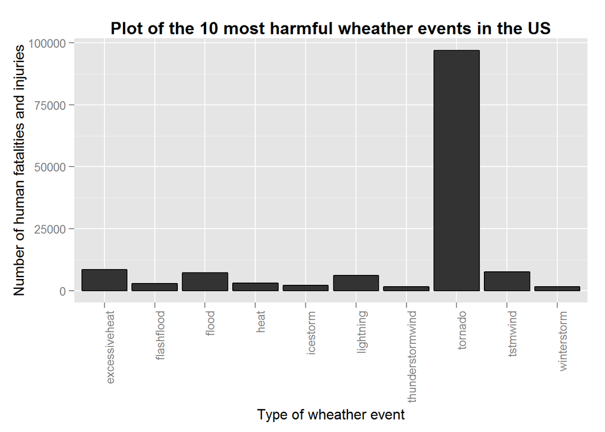

```r
answer1_short <- head(answer1, 10)
library(ggplot2)
ggplot(data=answer1_short, aes(x = EVTYPE, y = health)) +
    geom_bar(stat="identity", position=position_dodge(), colour="black") +
    ggtitle("Plot of the 10 most harmful wheather events in the US") +
    ylab("Number of human fatalities and injuries") +
    xlab("Type of wheather event") +
    theme(axis.text.x = element_text(angle = 90, hjust = 1)) +
    theme(plot.title = element_text(lineheight=.8, face="bold"))
```

The second question is as follows:

2. Across the United States, which types of events have the greatest economic consequences?

To answer this question we firstly have to group the dataset by type of event. After this we calculate the sum of the economic consequences containing different financial damages as PROPDMG and CROPDMG.

```r
needed$economic <- needed$PROPDMG + needed$CROPDMG

#group by Event type and sum up the health column
library(dplyr)
event_group <- group_by(needed, EVTYPE)
event_group_economic <- summarise(event_group,
    economic = sum(economic))
answer2 <- arrange(event_group_economic, desc(economic))
```

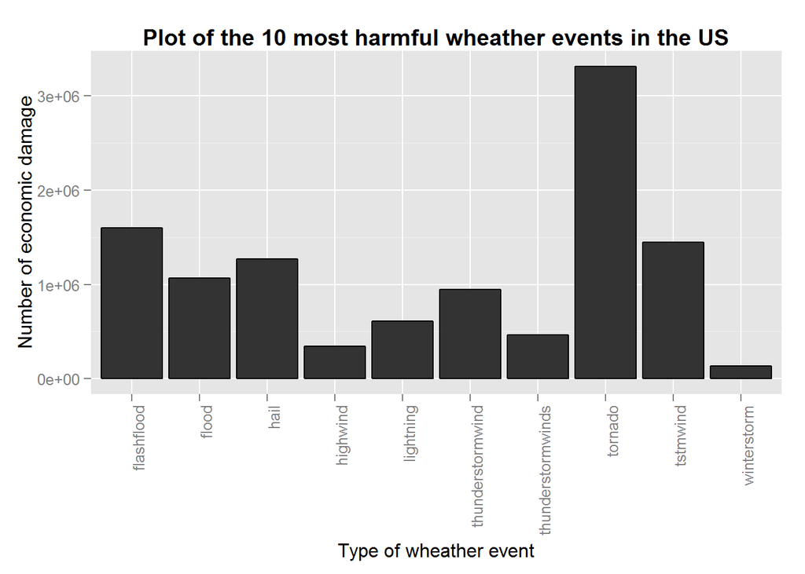

```r
answer2_short <- head(answer2, 10)
library(ggplot2)
ggplot(data=answer2_short, aes(x = EVTYPE, y = economic)) +
    geom_bar(stat="identity", position=position_dodge(), colour="black") +
    ggtitle("Plot of the 10 most harmful wheather events in the US") +
    ylab("Number of economic damage") +
    xlab("Type of wheather event") +
    theme(axis.text.x = element_text(angle = 90, hjust = 1)) +
    theme(plot.title = element_text(lineheight=.8, face="bold"))
```

## Results

As you can see the most harmful wheather event for both, the economy and humanity are tornados. After that the events that make up the most damage in any category are pretty diversified.